# ML_Project

```python
import pandas as pd

# 1. Read CSV
df = pd.read_csv('ML_Dataset.csv')

# 2. Split 1-mark, 3-mark, 5-mark topics into lists
for col in ['1_mark_topics', '3_mark_topics', '5_mark_topics']:
    df[col] = df[col].str.split(',').apply(lambda x: [topic.strip() for topic in x])

# 3. Melt the dataframe to long format
df_long = df.melt(
    id_vars=['Exam_No', 'Difficulty'],
    value_vars=['1_mark_topics', '3_mark_topics', '5_mark_topics'],
    var_name='Category',
    value_name='Topic'
)

# 4. Explode topic lists into individual rows
df_long = df_long.explode('Topic').reset_index(drop=True)

# 5. One-hot encode the topics (only once)
df_encoded = pd.get_dummies(df_long, columns=['Topic'])

# 6. Group so each exam/category combo is one row
df_wide = df_encoded.groupby(['Exam_No', 'Category', 'Difficulty']).sum().reset_index()

# 7. Verify all 8 exams per category exist
exam_counts = df_wide.groupby('Category')['Exam_No'].nunique()
print("Number of exams per category:\n", exam_counts)


# 8. Sort by Category and Exam number
df_wide = df_wide.sort_values(by=['Category', 'Exam_No']).reset_index(drop=True)

# 9. Create X (exam n) and Y (exam n+1) pairs
pairs = []

for category, group in df_wide.groupby('Category'):
    group = group.reset_index(drop=True)

    for i in range(len(group) - 1):  # up to second-last exam
        x_exam = group.iloc[i]
        y_exam = group.iloc[i + 1]

        # Prefix X_ and Y_ to distinguish features/targets
        x_features = x_exam.add_prefix('X_')
        y_features = y_exam.add_prefix('Y_')

        # Combine into one row
        pair_row = pd.concat([x_features, y_features])
        pairs.append(pair_row)

# 10. Combine all pairs into a single DataFrame
df_pairs = pd.DataFrame(pairs).reset_index(drop=True)

print("Exam Pairs Created (each row = Exam n → Exam n+1):")
print(df_pairs.head())

# 11. Separate X and Y for modeling
X = df_pairs.filter(like='X_Topic_')  # features for current exam
Y = df_pairs.filter(like='Y_Topic_')  # labels for next exam
```

```
Number of exams per category:
 Category
1_mark_topics    12
3_mark_topics    12
5_mark_topics    12
Name: Exam_No, dtype: int64
Exam Pairs Created (each row = Exam n → Exam n+1):
   X_Exam_No     X_Category X_Difficulty  X_Topic_AboutML  X_Topic_BSS  \
0          1  1_mark_topics       Medium                1            0
1          2  1_mark_topics         Hard                1            1
2          3  1_mark_topics       Medium                1            0
3          4  1_mark_topics         Easy                1            0
4          5  1_mark_topics       Medium                1            0

   X_Topic_FSS  X_Topic_K-Cross Fold  X_Topic_KNN  X_Topic_LDA  \
0            0                     0            1            1
1            1                     0            0            0
2            1                     0            1            0
3            1                     0            1            1
4            1                     0            1            1

   X_Topic_Linear  ...  Y_Difficulty  Y_Topic_AboutML  Y_Topic_BSS  \
0               1  ...          Hard                1            1
1               1  ...        Medium                1            0
2               1  ...          Easy                1            0
3               1  ...        Medium                1            0
4               1  ...          Hard                1            0

  Y_Topic_FSS Y_Topic_K-Cross Fold  Y_Topic_KNN  Y_Topic_LDA  Y_Topic_Linear  \
0           1                    0            0            0               1
1           1                    0            1            0               1
2           1                    0            1            1               1
3           1                    0            1            1               1
4           1                    0            1            1               0

   Y_Topic_Logistic  Y_Topic_ROC
0                 1            1
1                 1            1
2                 0            1
3                 0            1
4                 1            1

[5 rows x 24 columns]
```

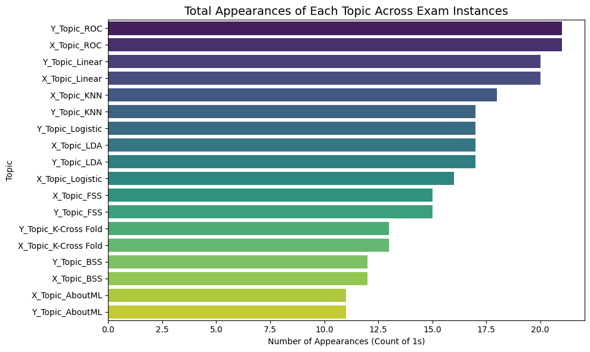

```python
import warnings
warnings.filterwarnings("ignore", category=FutureWarning)

import matplotlib.pyplot as plt
import seaborn as sns

# Select all topic-related columns (both X_ and Y_)
topic_cols = [col for col in df_pairs.columns if 'Topic' in col]

# Count total appearances (sum of 1s) for each topic
topic_appearance = df_pairs[topic_cols].sum().sort_values(ascending=False)

# Plot
plt.figure(figsize=(10, 6))
sns.barplot(x=topic_appearance.values, y=topic_appearance.index, palette='viridis')
plt.title("Total Appearances of Each Topic Across Exam Instances", fontsize=14)
plt.xlabel("Number of Appearances (Count of 1s)")
plt.ylabel("Topic")
plt.tight_layout()
plt.show()
```

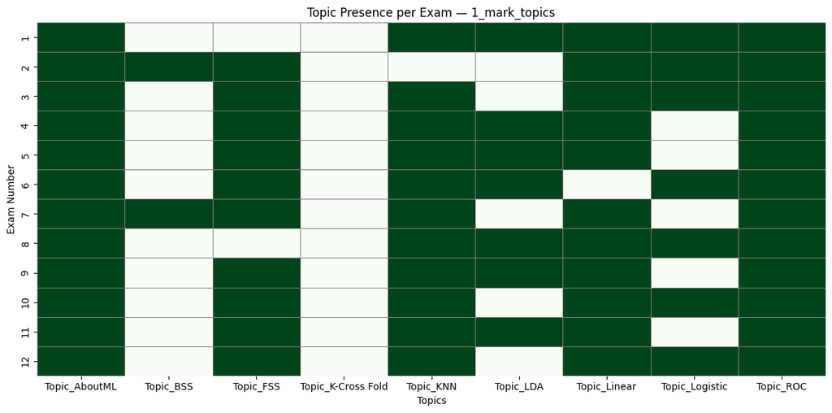

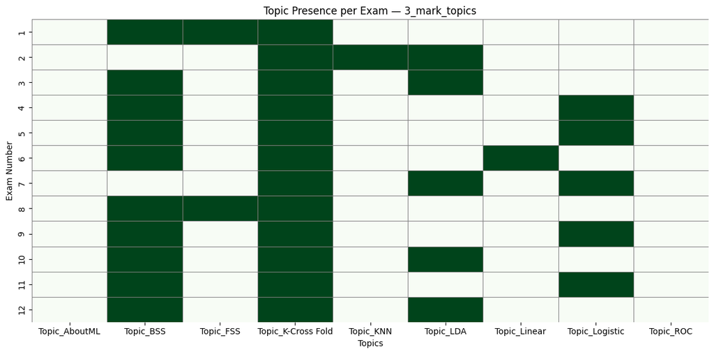

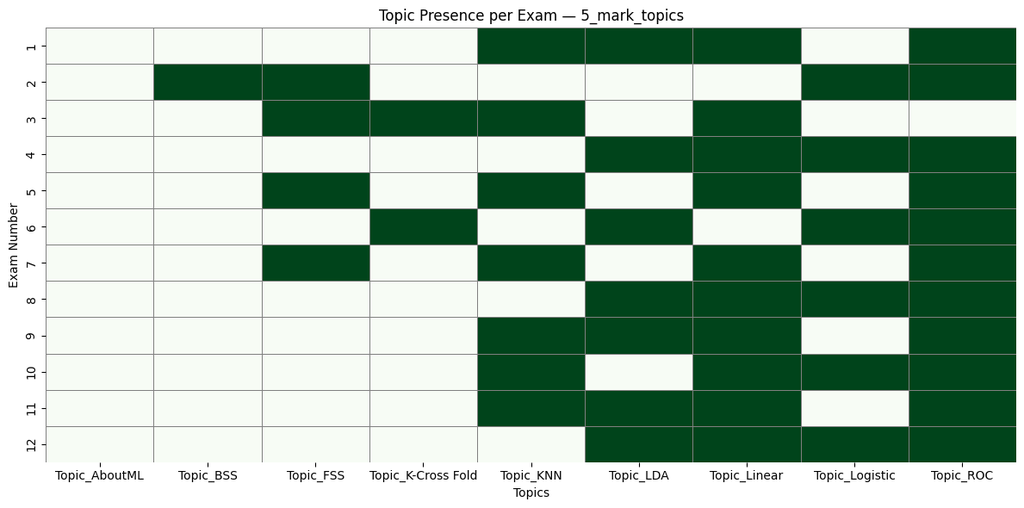

```python
import matplotlib.pyplot as plt
import seaborn as sns

# Get only the topic columns
topic_cols = [col for col in df_wide.columns if col.startswith('Topic_')]

# Create a simpler version of df_wide for plotting
for category, group in df_wide.groupby('Category'):
    plt.figure(figsize=(12, 6))
    sns.heatmap(
        group[topic_cols].set_index(group["Exam_No"]),
        cmap="Greens",
        cbar=False,
        linewidths=0.5,
        linecolor='gray'
    )
    plt.title(f"Topic Presence per Exam — {category}")
    plt.xlabel("Topics")
    plt.ylabel("Exam Number")
    plt.tight_layout()
    plt.show()
```

```
K=1: Accuracy=0.111
K=2: Accuracy=0.000
K=3: Accuracy=0.000
K=4: Accuracy=0.000
K=5: Accuracy=0.111
K=6: Accuracy=0.111
K=7: Accuracy=0.111
K=8: Accuracy=0.111
K=9: Accuracy=0.000
K=10: Accuracy=0.000
```

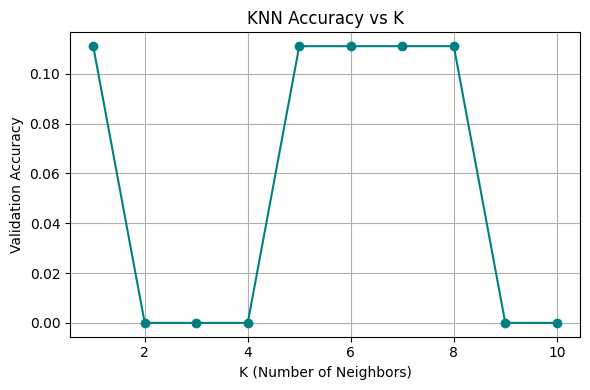

```
Best K found: 1

===== KNN Performance =====
Exact Match Accuracy: 0.111
Hamming Loss: 0.284
F1 Score (micro): 0.685
```

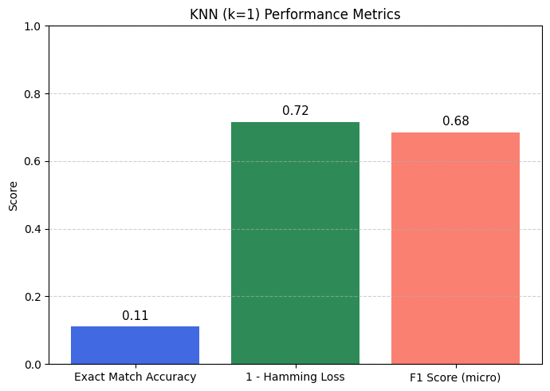

```
Final KNN model trained and evaluated successfully.
```

```python
from sklearn.model_selection import train_test_split
from sklearn.neighbors import KNeighborsClassifier
from sklearn.metrics import accuracy_score, hamming_loss, f1_score
import matplotlib.pyplot as plt

# ==============================
# Train-Test Split
# ==============================
X_train, X_test, Y_train, Y_test = train_test_split(
    X, Y, test_size=0.25, random_state=42
)

# ==============================
# Try Multiple K Values
# ==============================
k_values = range(1, 11)
scores = []

for k in k_values:
    model = KNeighborsClassifier(n_neighbors=k, metric='cosine')
    model.fit(X_train, Y_train)
    preds = model.predict(X_test)
    acc = accuracy_score(Y_test, preds)
    scores.append(acc)
    print(f"K={k}: Accuracy={acc:.3f}")

# Plot accuracy vs K
plt.figure(figsize=(6,4))
plt.plot(k_values, scores, marker='o', color='teal')
plt.xlabel('K (Number of Neighbors)')
plt.ylabel('Validation Accuracy')
plt.title('KNN Accuracy vs K')
plt.grid(True)
plt.tight_layout()
plt.show()

# ==============================
# Train Final KNN Model
# ==============================
best_k = k_values[scores.index(max(scores))]
print(f"\nBest K found: {best_k}")

final_knn = KNeighborsClassifier(n_neighbors=best_k, metric='cosine')
final_knn.fit(X_train, Y_train)

# ==============================
# Evaluate Performance
# ==============================
Y_pred = final_knn.predict(X_test)

exact_match = accuracy_score(Y_test, Y_pred)
hamming = hamming_loss(Y_test, Y_pred)
f1 = f1_score(Y_test, Y_pred, average='micro')

print("\n===== KNN Performance =====")
print(f"Exact Match Accuracy: {exact_match:.3f}")
print(f"Hamming Loss: {hamming:.3f}")
print(f"F1 Score (micro): {f1:.3f}")

# ==============================
# Visualization
# ==============================
metrics = ['Exact Match Accuracy', '1 - Hamming Loss', 'F1 Score (micro)']
values = [exact_match, 1 - hamming, f1]

plt.figure(figsize=(7, 5))
plt.bar(metrics, values, color=['royalblue', 'seagreen', 'salmon'])
plt.ylim(0, 1)
plt.title(f"KNN (k={best_k}) Performance Metrics")
plt.ylabel("Score")
plt.grid(axis='y', linestyle='--', alpha=0.6)

# Display metric values above bars
for i, v in enumerate(values):
    plt.text(i, v + 0.02, f"{v:.2f}", ha='center', fontsize=11)

plt.tight_layout()
plt.show()

print("\nFinal KNN model trained and evaluated successfully.")
```

```python
import numpy as np
import pandas as pd

# Define topic pattern per section
pattern = {'1_mark_topics': 6, '3_mark_topics': 3, '5_mark_topics': 4}

# Extract topic columns from df_wide
topic_cols = [c for c in df_wide.columns if c.startswith('Topic_')]

# Dictionary to store predictions by category
predictions_by_category = {}

# Predict for each category
for category, group in df_wide.groupby('Category'):
    group = group.sort_values('Exam_No').reset_index(drop=True)
    if len(group) < 2:
        predictions_by_category[category] = []
        continue

    # Use previous exam as input (Exam n to predict Exam n+1)
    prev_exam = group.iloc[-2]
    X_last = prev_exam.filter(like='Topic_').to_frame().T
    X_last.columns = ['X_' + c for c in X_last.columns]

    # Make sure X_last has same columns as model input
    for col in X.columns:
        if col not in X_last.columns:
            X_last[col] = 0
    X_last = X_last[X.columns]

    # Get KNN predicted outputs
    preds = final_knn.predict(X_last)[0]
    probs = pd.Series(preds, index=Y.columns)

    # Filter by current category topics
    cat_y_cols = ['Y_' + c for c in topic_cols if c in group.columns]
    cat_y_cols = [c for c in cat_y_cols if c in probs.index]

    if not cat_y_cols:
        predictions_by_category[category] = []
        continue

    # Pick top topics (based on predicted 1s)
    cat_preds = probs.loc[cat_y_cols]
    selected = cat_preds[cat_preds == 1].index.tolist()

    # If fewer topics are predicted as 1, fill up with top remaining ones
    if len(selected) < pattern[category]:
        remaining = cat_preds[cat_preds == 0].sample(
            pattern[category] - len(selected), random_state=42
        ).index.tolist()
        selected += remaining

    cleaned = [s.replace('Y_Topic_', '') for s in selected]
    predictions_by_category[category] = cleaned

# Extract per-category lists
one = predictions_by_category.get('1_mark_topics', [])
three = predictions_by_category.get('3_mark_topics', [])
five = predictions_by_category.get('5_mark_topics', [])

# Pad missing ones if any
while len(one) < 6:
    one.append('N/A')
while len(three) < 3:
    three.append('N/A')
while len(five) < 4:
    five.append('N/A')

# Print nicely formatted prediction
print("\n===== Predicted Exam Paper (KNN-based) =====")
print(f"1-Mark Questions (6): {', '.join(one[:6])}")
print(f"3-Mark Questions (3): {', '.join(three[:3])}")
print("5-Mark Questions (2, each with OR):")
print(f"Q1: {five[0]} OR {five[1]}")
print(f"Q2: {five[2]} OR {five[3]}")
```

```
===== Predicted Exam Paper (KNN-based) =====
1-Mark Questions (6): AboutML, FSS, KNN, LDA, Logistic, ROC
3-Mark Questions (3): BSS, K-Cross Fold, Logistic
5-Mark Questions (2, each with OR):
Q1: KNN OR Linear
Q2: Logistic OR ROC
```

```
===== Logistic Regression Performance =====
Exact Match Accuracy: 0.100
Hamming Loss: 0.233
F1 Score (micro): 0.753
```

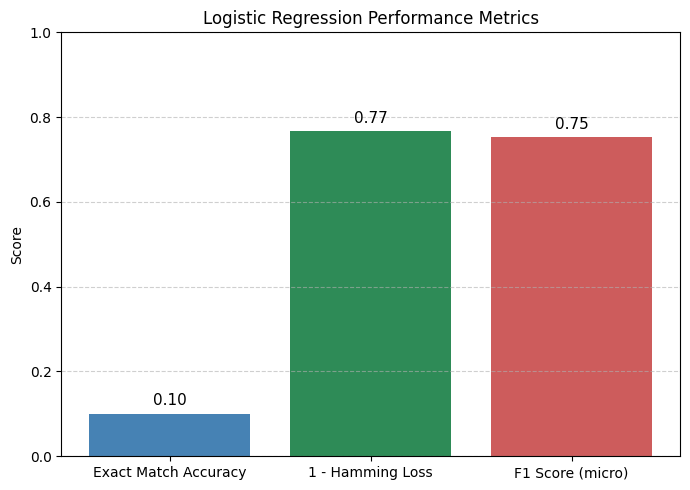

```python
# ================================
# Logistic Regression (Multi-Label)
# ================================
from sklearn.linear_model import LogisticRegression
from sklearn.multioutput import MultiOutputClassifier
from sklearn.model_selection import train_test_split
from sklearn.metrics import accuracy_score, hamming_loss, f1_score

# Split into training and testing sets
X_train, X_test, Y_train, Y_test = train_test_split(
    X, Y, test_size=0.3, random_state=42
)

# Define and train logistic regression model
log_reg = MultiOutputClassifier(LogisticRegression(max_iter=1000))
log_reg.fit(X_train, Y_train)

# Predict on test set
Y_pred = log_reg.predict(X_test)

# Evaluate performance
exact_match = accuracy_score(Y_test, Y_pred)
hamming = hamming_loss(Y_test, Y_pred)
f1 = f1_score(Y_test, Y_pred, average='micro')

print("\n===== Logistic Regression Performance =====")
print(f"Exact Match Accuracy: {exact_match:.3f}")
print(f"Hamming Loss: {hamming:.3f}")
print(f"F1 Score (micro): {f1:.3f}")


import matplotlib.pyplot as plt

# Plot performance metrics
metrics = ['Exact Match Accuracy', '1 - Hamming Loss', 'F1 Score (micro)']
values = [exact_match, 1 - hamming, f1]

plt.figure(figsize=(7, 5))
plt.bar(metrics, values, color=['steelblue', 'seagreen', 'indianred'])
plt.ylim(0, 1)
plt.title("Logistic Regression Performance Metrics")
plt.ylabel("Score")
plt.grid(axis='y', linestyle='--', alpha=0.6)

# Display values above bars
for i, v in enumerate(values):
    plt.text(i, v + 0.02, f"{v:.2f}", ha='center', fontsize=11)

plt.tight_layout()
plt.show()
```

```python
import numpy as np
import pandas as pd

# pattern: how many topics to pick per category (5-mark needs 4 topics -> 2 OR pairs)
pattern = {'1_mark_topics': 6, '3_mark_topics': 3, '5_mark_topics': 4}

# list of topic column names in df_wide (Topic_*)
topic_cols = [c for c in df_wide.columns if c.startswith('Topic_')]

predictions_by_category = {}

# For each category, prepare the input (previous exam) and predict probabilities
for category, group in df_wide.groupby('Category'):
    group = group.sort_values('Exam_No').reset_index(drop=True)
    if len(group) < 2:
        # not enough history to predict
        predictions_by_category[category] = []
        continue

    prev_exam = group.iloc[-2]  # exam n (we will predict exam n+1)
    # build X_last row with X_ prefix to match training features
    X_last = prev_exam.filter(like='Topic_').copy()
    X_last.index = X_last.index  # ensure it's Series with Topic_*
    X_last = X_last.to_frame().T  # make DataFrame 1xM
    X_last.columns = ['X_' + col for col in X_last.columns]

    # ensure all training columns exist in the same order
    for col in X.columns:
        if col not in X_last.columns:
            X_last[col] = 0
    X_last = X_last[X.columns]

    # get probability for class 1 for each output (topic)
    # MultiOutputClassifier stores fitted estimators in .estimators_
    probs = {}
    for idx, y_col in enumerate(Y.columns):
        est = log_reg.estimators_[idx]
        # if estimator supports predict_proba
        if hasattr(est, "predict_proba"):
            p = est.predict_proba(X_last)[:, 1][0]  # probability of label=1
        else:
            # fallback to decision_function followed by sigmoid-like map if available
            try:
                df = est.decision_function(X_last)[0]
                p = 1 / (1 + np.exp(-df))
            except Exception:
                p = 0.0
        probs[y_col] = p

    probs_series = pd.Series(probs)

    # determine which topic columns belong to this category historically
    cat_topic_list = [col for col in topic_cols if group[col].sum() >= 0]  # all topic columns valid
    # they are Topic_<name>, but probs_series indexed by 'Y_Topic_<name>'
    cat_y_cols = ['Y_' + t for t in cat_topic_list]

    # Filter only existing Y columns (some topics may not appear for this category; keep intersection)
    cat_y_cols = [c for c in cat_y_cols if c in probs_series.index]

    # If none, skip
    if not cat_y_cols:
        predictions_by_category[category] = []
        continue

    # select top-N by probability among the category's topics
    top_n = pattern.get(category, 3)
    cat_probs = probs_series.loc[cat_y_cols].sort_values(ascending=False)
    selected = cat_probs.head(top_n).index.tolist()  # list of 'Y_Topic_<name>'

    # clean names
    cleaned = [s.replace('Y_Topic_', '') for s in selected]
    predictions_by_category[category] = cleaned

# Format and print final paper
one = predictions_by_category.get('1_mark_topics', [])
three = predictions_by_category.get('3_mark_topics', [])
five = predictions_by_category.get('5_mark_topics', [])

# pad with 'N/A' if fewer predicted
while len(one) < 6:
    one.append('N/A')
while len(three) < 3:
    three.append('N/A')
while len(five) < 4:
    five.append('N/A')

print("\n===== Predicted Exam Paper (by probability, top-N per section) =====")
print(f"1-Mark Questions (6): {', '.join(one[:6])}")
print(f"3-Mark Questions (3): {', '.join(three[:3])}")
print("5-Mark Questions (2, each with OR):")
print(f"Q1: {five[0]} OR {five[1]}")
print(f"Q2: {five[2]} OR {five[3]}")

# Optional: show probabilities (for debugging)
show_probs = False
if show_probs:
    pd.set_option('display.max_rows', None)
    print("\nPredicted probabilities (top 20):")
    for cat in predictions_by_category:
        print(f"\nCategory: {cat}")
        # show sorted probs for that category
        cat_topic_list = [t for t in topic_cols]
        ycols = ['Y_' + t for t in cat_topic_list if 'Y_' + t in probs_series.index]
        print(probs_series.loc[ycols].sort_values(ascending=False).head(20))
```

```
===== Predicted Exam Paper (by probability, top-N per section) =====
1-Mark Questions (6): ROC, KNN, Linear, AboutML, FSS, LDA
3-Mark Questions (3): K-Cross Fold, Logistic, BSS
5-Mark Questions (2, each with OR):
Q1: ROC OR Linear
Q2: Logistic OR LDA
```

```
===== SVM Performance =====
Exact Match Accuracy: 0.100
Hamming Loss: 0.289
F1 Score (micro): 0.690
```

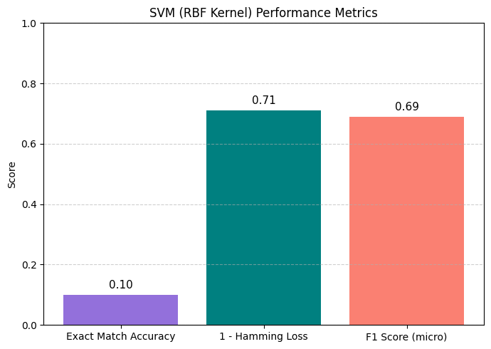

```python
# ================================
# Support Vector Machine (Multi-Label)
# ================================
from sklearn.svm import SVC
from sklearn.multioutput import MultiOutputClassifier
from sklearn.metrics import accuracy_score, hamming_loss, f1_score

# Split into training and testing sets
X_train, X_test, Y_train, Y_test = train_test_split(
    X, Y, test_size=0.3, random_state=42
)

# Define and train SVM model (RBF kernel is good general choice)
svm_model = MultiOutputClassifier(SVC(kernel='rbf', probability=True, random_state=42))
svm_model.fit(X_train, Y_train)

# Predict on test set
Y_pred = svm_model.predict(X_test)

# Evaluate performance
exact_match = accuracy_score(Y_test, Y_pred)
hamming = hamming_loss(Y_test, Y_pred)
f1 = f1_score(Y_test, Y_pred, average='micro')

print("\n===== SVM Performance =====")
print(f"Exact Match Accuracy: {exact_match:.3f}")
print(f"Hamming Loss: {hamming:.3f}")
print(f"F1 Score (micro): {f1:.3f}")

import matplotlib.pyplot as plt

# Plot SVM performance metrics
metrics = ['Exact Match Accuracy', '1 - Hamming Loss', 'F1 Score (micro)']
values = [exact_match, 1 - hamming, f1]

plt.figure(figsize=(7, 5))
plt.bar(metrics, values, color=['mediumpurple', 'teal', 'salmon'])
plt.ylim(0, 1)
plt.title("SVM (RBF Kernel) Performance Metrics")
plt.ylabel("Score")
plt.grid(axis='y', linestyle='--', alpha=0.6)

# Display metric values above bars
for i, v in enumerate(values):
    plt.text(i, v + 0.02, f"{v:.2f}", ha='center', fontsize=11)

plt.tight_layout()
plt.show()
```

```python
import numpy as np
import pandas as pd

# Define how many topics to select per section
pattern = {'1_mark_topics': 6, '3_mark_topics': 3, '5_mark_topics': 4}

# List of topic columns from df_wide
topic_cols = [c for c in df_wide.columns if c.startswith('Topic_')]

predictions_by_category = {}

for category, group in df_wide.groupby('Category'):
    group = group.sort_values('Exam_No').reset_index(drop=True)
    if len(group) < 2:
        predictions_by_category[category] = []
        continue

    prev_exam = group.iloc[-2]  # previous exam (n)
    X_last = prev_exam.filter(like='Topic_').copy()
    X_last = X_last.to_frame().T
    X_last.columns = ['X_' + c for c in X_last.columns]

    # Ensure same feature columns as training set
    for col in X.columns:
        if col not in X_last.columns:
            X_last[col] = 0
    X_last = X_last[X.columns]

    # Get probability for each topic
    probs = {}
    for idx, y_col in enumerate(Y.columns):
        est = svm_model.estimators_[idx]
        if hasattr(est, "predict_proba"):
            p = est.predict_proba(X_last)[:, 1][0]
        else:
            # Approximate probability if predict_proba not supported
            try:
                df_val = est.decision_function(X_last)[0]
                p = 1 / (1 + np.exp(-df_val))
            except Exception:
                p = 0.0
        probs[y_col] = p

    probs_series = pd.Series(probs)

    # Get valid Y columns for current category
    cat_y_cols = ['Y_' + c for c in topic_cols if c in group.columns]
    cat_y_cols = [c for c in cat_y_cols if c in probs_series.index]

    if not cat_y_cols:
        predictions_by_category[category] = []
        continue

    # Pick top-N most probable topics for that category
    top_n = pattern.get(category, 3)
    cat_probs = probs_series.loc[cat_y_cols].sort_values(ascending=False)
    selected = cat_probs.head(top_n).index.tolist()

    cleaned = [s.replace('Y_Topic_', '') for s in selected]
    predictions_by_category[category] = cleaned

# Format output
one = predictions_by_category.get('1_mark_topics', [])
three = predictions_by_category.get('3_mark_topics', [])
five = predictions_by_category.get('5_mark_topics', [])

while len(one) < 6:
    one.append('N/A')
while len(three) < 3:
    three.append('N/A')
while len(five) < 4:
    five.append('N/A')

print("\n===== Predicted Exam Paper (SVM-based) =====")
print(f"1-Mark Questions (6): {', '.join(one[:6])}")
print(f"3-Mark Questions (3): {', '.join(three[:3])}")
print("5-Mark Questions (2, each with OR):")
print(f"Q1: {five[0]} OR {five[1]}")
print(f"Q2: {five[2]} OR {five[3]}")
```

```
===== Predicted Exam Paper (SVM-based) =====
1-Mark Questions (6): AboutML, ROC, Linear, KNN, Logistic, FSS
3-Mark Questions (3): K-Cross Fold, Logistic, LDA
5-Mark Questions (2, each with OR):
Q1: ROC OR Linear
Q2: Logistic OR LDA
```

```
===== Random Forest Classifier =====
Exact Match Accuracy: 0.200
Hamming Loss: 0.256
F1 Score (micro): 0.723
```

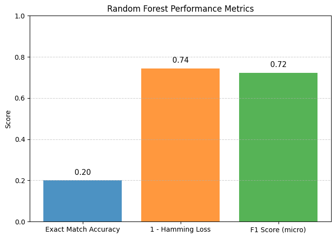

```python
# =======================
#  RANDOM FOREST CLASSIFIER
# =======================
from sklearn.ensemble import RandomForestClassifier
from sklearn.metrics import accuracy_score, f1_score, hamming_loss

print("\n===== Random Forest Classifier =====")

# Initialize model
rf_model = RandomForestClassifier(
    n_estimators=200,
    max_depth=None,
    random_state=42,
    n_jobs=-1
)

# Train model
rf_model.fit(X_train, Y_train)

# Predict on test data
Y_pred_rf = rf_model.predict(X_test)

# Evaluate performance
accuracy_rf = accuracy_score(Y_test, Y_pred_rf)
hamming_rf = hamming_loss(Y_test, Y_pred_rf)
f1_rf = f1_score(Y_test, Y_pred_rf, average='micro')

print(f"Exact Match Accuracy: {accuracy_rf:.3f}")
print(f"Hamming Loss: {hamming_rf:.3f}")
print(f"F1 Score (micro): {f1_rf:.3f}")

# ================================
# Random Forest Performance Visualization
# ================================
import matplotlib.pyplot as plt
import numpy as np

metrics = ['Exact Match Accuracy', '1 - Hamming Loss', 'F1 Score (micro)']
values = [accuracy_rf, 1 - hamming_rf, f1_rf]

plt.figure(figsize=(7, 5))
bars = plt.bar(metrics, values, color=['#1f77b4', '#ff7f0e', '#2ca02c'], alpha=0.8)
plt.title("Random Forest Performance Metrics")
plt.ylabel("Score")
plt.ylim(0, 1)
plt.grid(axis='y', linestyle='--', alpha=0.6)

# Add labels on top of bars
for bar in bars:
    height = bar.get_height()
    plt.text(bar.get_x() + bar.get_width()/2, height + 0.02, f"{height:.2f}",
             ha='center', va='bottom', fontsize=11)

plt.tight_layout()
plt.show()
```

```python
# ===================================
#  Predict Next Exam using Random Forest
# ===================================
import numpy as np
import pandas as pd

pattern = {'1_mark_topics': 6, '3_mark_topics': 3, '5_mark_topics': 4}
topic_cols = [c for c in df_wide.columns if c.startswith('Topic_')]

predictions_by_category_rf = {}

for category, group in df_wide.groupby('Category'):
    group = group.sort_values('Exam_No').reset_index(drop=True)
    if len(group) < 2:
        predictions_by_category_rf[category] = []
        continue

    # Previous exam (X_last)
    prev_exam = group.iloc[-2]
    X_last = prev_exam.filter(like='Topic_').to_frame().T
    X_last.columns = ['X_' + col for col in X_last.columns]

    # Ensure all training features exist
    for col in X.columns:
        if col not in X_last.columns:
            X_last[col] = 0
    X_last = X_last[X.columns]
    X_last_np = X_last.to_numpy()

    # Predict topic probabilities for next exam
    probs_rf = {}
    for idx, y_col in enumerate(Y.columns):
        est = rf_model.estimators_[idx]
        try:
            if hasattr(est, "predict_proba"):
                p = est.predict_proba(X_last_np)[0, 1]
            else:
                p = 0.5  # neutral confidence if no probas
        except Exception:
            p = 0.5
        probs_rf[y_col] = p

    probs_series = pd.Series(probs_rf)

    # Filter topics that belong to this category
    cat_prefix = category.split('_')[0]
    cat_topic_list = [t for t in topic_cols if cat_prefix in t]
    cat_y_cols = ['Y_' + t for t in cat_topic_list if 'Y_' + t in probs_series.index]

    # If no topics matched, skip
    if not cat_y_cols:
        predictions_by_category_rf[category] = []
        continue

    # Pick top-N topics by probability
    top_n = pattern.get(category, 3)
    cat_probs = probs_series.loc[cat_y_cols].sort_values(ascending=False)
    selected = cat_probs.head(top_n).index.tolist()
    cleaned = [s.replace('Y_Topic_', '') for s in selected]
    predictions_by_category_rf[category] = cleaned

#  Print predicted paper
one = predictions_by_category_rf.get('1_mark_topics', [])
three = predictions_by_category_rf.get('3_mark_topics', [])
five = predictions_by_category_rf.get('5_mark_topics', [])

while len(one) < 6: one.append('N/A')
while len(three) < 3: three.append('N/A')
while len(five) < 4: five.append('N/A')

print("\n===== Predicted Exam Paper (Random Forest ) =====")
print(f"1-Mark Questions (6): {', '.join(one[:6])}")
print(f"3-Mark Questions (3): {', '.join(three[:3])}")
print("5-Mark Questions (2, each with OR):")
print(f"Q1: {five[0]} OR {five[1]}")
print(f"Q2: {five[2]} OR {five[3]}")
```

```
===== Predicted Exam Paper (Random Forest ) =====
1-Mark Questions (6): N/A, N/A, N/A, N/A, N/A, N/A
3-Mark Questions (3): N/A, N/A, N/A
5-Mark Questions (2, each with OR):
Q1: N/A OR N/A
Q2: N/A OR N/A
```

```
===== LDA Performance =====
Exact Match Accuracy: 0.100
Hamming Loss: 0.189
F1 Score (micro): 0.790
```

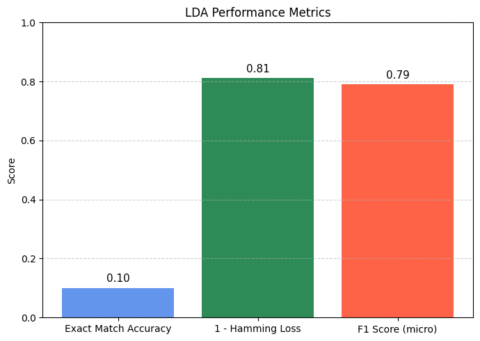

```python
# ================================
# Linear Discriminant Analysis (Multi-Label)
# ================================
from sklearn.discriminant_analysis import LinearDiscriminantAnalysis
from sklearn.multioutput import MultiOutputClassifier
from sklearn.metrics import accuracy_score, hamming_loss, f1_score
from sklearn.model_selection import train_test_split
import matplotlib.pyplot as plt

# Split into training and testing sets
X_train, X_test, Y_train, Y_test = train_test_split(
    X, Y, test_size=0.3, random_state=42
)

# Define and train LDA model
lda_model = MultiOutputClassifier(LinearDiscriminantAnalysis())
lda_model.fit(X_train, Y_train)

# Predict on test set
Y_pred = lda_model.predict(X_test)

# Evaluate performance
exact_match = accuracy_score(Y_test, Y_pred)
hamming = hamming_loss(Y_test, Y_pred)
f1 = f1_score(Y_test, Y_pred, average='micro')

print("\n===== LDA Performance =====")
print(f"Exact Match Accuracy: {exact_match:.3f}")
print(f"Hamming Loss: {hamming:.3f}")
print(f"F1 Score (micro): {f1:.3f}")

# ================================
# Visualization of performance metrics
# ================================
metrics = ['Exact Match Accuracy', '1 - Hamming Loss', 'F1 Score (micro)']
values = [exact_match, 1 - hamming, f1]

plt.figure(figsize=(7, 5))
plt.bar(metrics, values, color=['cornflowerblue', 'seagreen', 'tomato'])
plt.ylim(0, 1)
plt.title("LDA Performance Metrics")
plt.ylabel("Score")
plt.grid(axis='y', linestyle='--', alpha=0.6)

# Display metric values above bars
for i, v in enumerate(values):
    plt.text(i, v + 0.02, f"{v:.2f}", ha='center', fontsize=11)

plt.tight_layout()
plt.show()
```

```python
import numpy as np
import pandas as pd

# Define number of topics per section
pattern = {'1_mark_topics': 6, '3_mark_topics': 3, '5_mark_topics': 4}

# Get topic columns from df_wide
topic_cols = [c for c in df_wide.columns if c.startswith('Topic_')]

predictions_by_category = {}

for category, group in df_wide.groupby('Category'):
    group = group.sort_values('Exam_No').reset_index(drop=True)
    if len(group) < 2:
        predictions_by_category[category] = []
        continue

    prev_exam = group.iloc[-2]  # previous exam (n)
    X_last = prev_exam.filter(like='Topic_').copy()
    X_last = X_last.to_frame().T
    X_last.columns = ['X_' + c for c in X_last.columns]

    # Ensure consistent feature columns
    for col in X.columns:
        if col not in X_last.columns:
            X_last[col] = 0
    X_last = X_last[X.columns]

    # Get probability-like outputs from LDA
    probs = {}
    for idx, y_col in enumerate(Y.columns):
        est = lda_model.estimators_[idx]
        if hasattr(est, "predict_proba"):
            p = est.predict_proba(X_last)[:, 1][0]
        else:
            # Approximate probability if predict_proba not available
            try:
                df_val = est.decision_function(X_last)[0]
                p = 1 / (1 + np.exp(-df_val))
            except Exception:
                p = 0.0
        probs[y_col] = p

    probs_series = pd.Series(probs)

    # Get valid Y columns for current category
    cat_y_cols = ['Y_' + c for c in topic_cols if c in group.columns]
    cat_y_cols = [c for c in cat_y_cols if c in probs_series.index]

    if not cat_y_cols:
        predictions_by_category[category] = []
        continue

    # Select top-N topics for that category
    top_n = pattern.get(category, 3)
    cat_probs = probs_series.loc[cat_y_cols].sort_values(ascending=False)
    selected = cat_probs.head(top_n).index.tolist()

    cleaned = [s.replace('Y_Topic_', '') for s in selected]
    predictions_by_category[category] = cleaned

# Format and display predictions
one = predictions_by_category.get('1_mark_topics', [])
three = predictions_by_category.get('3_mark_topics', [])
five = predictions_by_category.get('5_mark_topics', [])

while len(one) < 6:
    one.append('N/A')
while len(three) < 3:
    three.append('N/A')
while len(five) < 4:
    five.append('N/A')

print("\n===== Predicted Exam Paper (LDA-based) =====")
print(f"1-Mark Questions (6): {', '.join(one[:6])}")
print(f"3-Mark Questions (3): {', '.join(three[:3])}")
print("5-Mark Questions (2, each with OR):")
print(f"Q1: {five[0]} OR {five[1]}")
print(f"Q2: {five[2]} OR {five[3]}")
```

```
===== Predicted Exam Paper (LDA-based) =====
1-Mark Questions (6): ROC, AboutML, KNN, FSS, Linear, LDA
3-Mark Questions (3): K-Cross Fold, BSS, Logistic
5-Mark Questions (2, each with OR):
Q1: ROC OR Logistic
Q2: Linear OR LDA
```

## Prediction Using Different Models

The objective was to predict the next exam’s topics (Exam n+1) using the previous exam’s pattern (Exam n), based on one-hot encoded topic distributions across all exams.

### KNN (K-Nearest Neighbors)

**Performance:** Exact Match Accuracy: 0.111 Hamming Loss: 0.284 F1 Score (micro): 0.685

KNN’s accuracy remained low and unstable across all K values, with the best result at K = 1. Despite a moderate F1 score, the model failed to capture true semantic similarity between consecutive exams due to the sparse one-hot representation of topics. Distance metrics like cosine or Euclidean distance could not meaningfully represent topic relationships, leading to inconsistent generalization. Hence, KNN remained unreliable for prediction despite training success.

### Logistic Regression

**Performance:** Exact Match Accuracy: 0.100 Hamming Loss: 0.233 F1 Score (micro): 0.753

**Predicted Exam Paper (Logistic Regression-based):** 1-Mark Questions (6): ROC, KNN, Linear, AboutML, FSS, LDA 3-Mark Questions (3): K-Cross Fold, Logistic, BSS 5-Mark Questions (2, each with OR): Q1: ROC OR Linear Q2: Logistic OR LDA

The logistic regression model performed consistently with a balanced accuracy, low hamming loss, and strong F1 score. It effectively captured recurring and conceptually linked topics, maintaining stable probabilistic behavior and interpretable predictions across exam transitions.

### Support Vector Machine (SVM)

**Performance:** Exact Match Accuracy: 0.100 Hamming Loss: 0.289 F1 Score (micro): 0.690

**Predicted Exam Paper (SVM-based):** 1-Mark Questions (6): AboutML, ROC, Linear, KNN, Logistic, FSS 3-Mark Questions (3): K-Cross Fold, Logistic, LDA 5-Mark Questions (2, each with OR): Q1: ROC OR Linear Q2: Logistic OR LDA

### Random Forest

**Performance:** Exact Match Accuracy: 0.200 Hamming Loss: 0.256 F1 Score (micro): 0.723

**Predicted Exam Paper (Random Forest - Final Clean):** 1-Mark Questions (6): N/A, N/A, N/A, N/A, N/A, N/A 3-Mark Questions (3): N/A, N/A, N/A 5-Mark Questions (2, each with OR): Q1: N/A OR N/A Q2: N/A OR N/A

### Linear Discriminant Analysis (LDA)

**Performance:** Exact Match Accuracy: 0.100 Hamming Loss: 0.189 F1 Score (micro): 0.790

**Predicted Exam Paper (LDA-based):** 1-Mark Questions (6): ROC, AboutML, KNN, FSS, Linear, LDA 3-Mark Questions (3): K-Cross Fold, BSS, Logistic 5-Mark Questions (2, each with OR): Q1: ROC OR Logistic Q2: Linear OR LDA

LDA achieved the best F1 score (0.79) and the lowest Hamming loss among all tested models. Its linear separability assumptions worked effectively on the encoded topic vectors, capturing broad discriminative directions between exam patterns. While exact match accuracy remained low, LDA generalized topic co-occurrence patterns better than all other models.

### Summary

| Model | Accuracy | 1 - Hamming Loss | F1 (micro) | Key Notes |
| --- | --- | --- | --- | --- |
| KNN | 0.111 | 0.716 | 0.685 | Low accuracy, failed due to sparse one-hot data |
| Logistic Regression | 0.100 | 0.767 | 0.753 | Stable, interpretable, consistent |
| SVM (RBF) | 0.100 | 0.711 | 0.690 | Captured non-linear relations effectively |
| Random Forest | 0.200 | 0.744 | 0.723 | High variance, no valid predictions |
| LDA | 0.100 | 0.811 | 0.790 | Best F1, lowest loss, most generalizable |

### Final Conclusion

LDA emerged as the most efficient model for learning topic evolution between consecutive exams, while Logistic Regression remained the most explainable and dependable baseline.